# 1. Applying Descision Trees

```python
%matplotlib inline
import warnings
warnings.filterwarnings("ignore")

import sqlite3
import pandas as pd
import numpy as np
import nltk
import string
import matplotlib.pyplot as plt
import seaborn as sns
from sklearn.feature_extraction.text import TfidfTransformer
from sklearn.feature_extraction.text import TfidfVectorizer

from sklearn.feature_extraction.text import CountVectorizer
from sklearn.metrics import confusion_matrix
from sklearn import metrics
from sklearn.metrics import roc_curve, auc
from nltk.stem.porter import PorterStemmer

import re
# Tutorial about Python regular expressions: https://pymotw.com/2/re/
import string
from nltk.corpus import stopwords
from nltk.stem import PorterStemmer
from nltk.stem.wordnet import WordNetLemmatizer

from gensim.models import Word2Vec
from gensim.models import KeyedVectors
import pickle

from tqdm import tqdm
import os

#from plotly import plotly
import plotly.offline as offline
import plotly.graph_objs as go
from collections import Counter

import nltk
nltk.download('vader_lexicon')
from nltk.sentiment.vader import SentimentIntensityAnalyzer
```

```python
#refer: https://en.wikipedia.org/wiki/GloVe
with open('C:/Users/rohin/AAIC/Git/donors_choose/glove_vectors', 'rb') as f:
    model = pickle.load(f)
    glove_words =  set(model.keys())
```

## 1.1 Loading Data

```python
import pandas
data = pandas.read_csv('C:/Users/rohin/AAIC/Git/donors_choose/preprocessed_data.csv',nrows=100000)
```

```python
# please write all the code with proper documentation, and proper titles for each subsection
# go through documentations and blogs before you start coding
# first figure out what to do, and then think about how to do.
# reading and understanding error messages will be very much helpfull in debugging your code
# when you plot any graph make sure you use
    # a. Title, that describes your plot, this will be very helpful to the reader
    # b. Legends if needed
    # c. X-axis label
    # d. Y-axis label
print(data.columns)
```

```
Index(['school_state', 'teacher_prefix', 'project_grade_category',
       'teacher_number_of_previously_posted_projects', 'project_is_approved',
       'clean_categories', 'clean_subcategories', 'essay', 'price'],
      dtype='object')
```

```python
print(data['essay'].head(1).values)
```

```
['i fortunate enough use fairy tale stem kits classroom well stem journals students really enjoyed i would love implement lakeshore stem kits classroom next school year provide excellent engaging stem lessons my students come variety backgrounds including language socioeconomic status many not lot e…
```

### Preprocessing essay

```python
import re

def decontracted(phrase):
    # specific
    phrase = re.sub(r"won't", "will not", phrase)
    phrase = re.sub(r"can\'t", "can not", phrase)

    # general
    phrase = re.sub(r"n\'t", " not", phrase)
    phrase = re.sub(r"\'re", " are", phrase)
    phrase = re.sub(r"\'s", " is", phrase)
    phrase = re.sub(r"\'d", " would", phrase)
    phrase = re.sub(r"\'ll", " will", phrase)
    phrase = re.sub(r"\'t", " not", phrase)
    phrase = re.sub(r"\'ve", " have", phrase)
    phrase = re.sub(r"\'m", " am", phrase)
    return phrase
```

```python
# https://gist.github.com/sebleier/554280
# we are removing the words from the stop words list: 'no', 'nor', 'not'
#added nan to the stop words
stopwords= ['i', 'me', 'my', 'myself', 'we', 'our', 'ours', 'ourselves', 'you', "you're", "you've",\
            "you'll", "you'd", 'your', 'yours', 'yourself', 'yourselves', 'he', 'him', 'his', 'himself', \
            'she', "she's", 'her', 'hers', 'herself', 'it', "it's", 'its', 'itself', 'they', 'them', 'their',\
            'theirs', 'themselves', 'what', 'which', 'who', 'whom', 'this', 'that', "that'll", 'these', 'those', \
            'am', 'is', 'are', 'was', 'were', 'be', 'been', 'being', 'have', 'has', 'had', 'having', 'do', 'does', \
            'did', 'doing', 'a', 'an', 'the', 'and', 'but', 'if', 'or', 'because', 'as', 'until', 'while', 'of', \
            'at', 'by', 'for', 'with', 'about', 'against', 'between', 'into', 'through', 'during', 'before', 'after',\
            'above', 'below', 'to', 'from', 'up', 'down', 'in', 'out', 'on', 'off', 'over', 'under', 'again', 'further',\
            'then', 'once', 'here', 'there', 'when', 'where', 'why', 'how', 'all', 'any', 'both', 'each', 'few', 'more',\
            'most', 'other', 'some', 'such', 'only', 'own', 'same', 'so', 'than', 'too', 'very', \
            's', 't', 'can', 'will', 'just', 'don', "don't", 'should', "should've", 'now', 'd', 'll', 'm', 'o', 're', \
            've', 'y', 'ain', 'aren', "aren't", 'couldn', "couldn't", 'didn', "didn't", 'doesn', "doesn't", 'hadn',\
            "hadn't", 'hasn', "hasn't", 'haven', "haven't", 'isn', "isn't", 'ma', 'mightn', "mightn't", 'mustn',\
            "mustn't", 'needn', "needn't", 'shan', "shan't", 'shouldn',"nan","nannan", "shouldn't", 'wasn', "wasn't", 'weren', "weren't", \
            'won', "won't", 'wouldn', "wouldn't"]
```

```python
# Combining all the above stundents
from tqdm import tqdm
def preprocess_text(text_data):
    preprocessed_text = []
    # tqdm is for printing the status bar
    for sentance in tqdm(text_data):
        sent = decontracted(sentance)
        sent = sent.replace('\\r', ' ')
        sent = sent.replace('\\n', ' ')
        sent = sent.replace('\\"', ' ')
        sent = re.sub('[^A-Za-z0-9]+', ' ', sent)
        # https://gist.github.com/sebleier/554280
        sent = ' '.join(e for e in sent.split() if e.lower() not in stopwords)
        preprocessed_text.append(sent.lower().strip())
    return preprocessed_text
```

```python
preprocessed_essays = preprocess_text(data['essay'].values)
```

```python
data['preprocessed_essays'] = preprocessed_essays
print(data['preprocessed_essays'].head(1).values)
```

```
['fortunate enough use fairy tale stem kits classroom well stem journals students really enjoyed would love implement lakeshore stem kits classroom next school year provide excellent engaging stem lessons students come variety backgrounds including language socioeconomic status many not lot experien…
```

## 1.2 Splitting data into Train and cross validation(or test): Stratified Sampling

```python
y = data['project_is_approved'].values #class label
X = data.drop(['project_is_approved'], axis=1) #data points
X.head(1)
```

|  | school_state | teacher_prefix | project_grade_category | teacher_number_of_previously_posted_projects | clean_categories | clean_subcategories | essay | price | preprocessed_essays |
| --- | --- | --- | --- | --- | --- | --- | --- | --- | --- |
| 0 | ca | mrs | grades_prek_2 | 53 | math_science | appliedsciences health_lifescience | i fortunate enough use fairy tale stem kits cl... | 725.05 | fortunate enough use fairy tale stem kits clas... |

```python
#splitting data into X_train, X_test, y_train, y_test
from sklearn.model_selection import train_test_split
x_train,x_test,y_train,y_test=train_test_split(
    X,
    y,
    test_size=0.2,
    random_state=42,
    stratify=y)
print("x_train: ",x_train.shape)
print("x_test : ",x_test.shape)
print("y_train: ",y_train.shape)
print("y_test : ",y_test.shape)
```

```
x_train:  (80000, 9)
x_test :  (20000, 9)
y_train:  (80000,)
y_test :  (20000,)
```

## 2. Preparing data for models

### 2.1 Vectorizing Categorical data

### 2.1.1 Vectorizing Categorical data :Clean Subject Categories

```python
# count of all the words in corpus python: https://stackoverflow.com/a/22898595/4084039
my_counter = Counter()
for word in data['clean_categories'].values:
    my_counter.update(word.split())

cat_dict = dict(my_counter)
sorted_cat_dict = dict(sorted(cat_dict.items(), key=lambda kv: kv[1]))
print(sorted_cat_dict)
```

```
{'warmth': 1119, 'care_hunger': 1119, 'history_civics': 5445, 'music_arts': 9469, 'appliedlearning': 10837, 'specialneeds': 12392, 'health_sports': 13422, 'math_science': 38007, 'literacy_language': 47896}
```

```python
vectorizer_cat = CountVectorizer(vocabulary=list(sorted_cat_dict.keys()), lowercase=False, binary=True)
vectorizer_cat.fit(x_train['clean_categories'].values) # fit has to happen only on train data

# we use the fitted CountVectorizer to convert the text to vector
X_train_categories_one_hot = vectorizer_cat.transform(x_train['clean_categories'].values)
#X_cv_grade_ohe = vectorizer.transform(X_cv['project_grade_category'].values)
X_test_categories_one_hot = vectorizer_cat.transform(x_test['clean_categories'].values)

print("After vectorizations")
print(X_train_categories_one_hot.shape, y_train.shape)
#print(X_cv_grade_ohe.shape, y_cv.shape)
print(X_test_categories_one_hot.shape, y_test.shape)
print(vectorizer_cat.get_feature_names())
```

```
After vectorizations
(80000, 9) (80000,)
(20000, 9) (20000,)
['warmth', 'care_hunger', 'history_civics', 'music_arts', 'appliedlearning', 'specialneeds', 'health_sports', 'math_science', 'literacy_language']
```

### 2.1.2 Vectorizing Categorical data :Clean Subject subCategories

```python
# count of all the words in corpus python: https://stackoverflow.com/a/22898595/4084039
my_counter = Counter()
for word in data['clean_subcategories'].values:
    my_counter.update(word.split())

sub_cat_dict = dict(my_counter)
sorted_sub_cat_dict = dict(sorted(sub_cat_dict.items(), key=lambda kv: kv[1]))
print(sorted_sub_cat_dict)
```

```
{'economics': 255, 'communityservice': 407, 'financialliteracy': 491, 'parentinvolvement': 605, 'extracurricular': 713, 'civics_government': 763, 'foreignlanguages': 822, 'warmth': 1119, 'care_hunger': 1119, 'nutritioneducation': 1323, 'socialsciences': 1784, 'performingarts': 1791, 'charactereducat…
```

```python
vectorizer_sub = CountVectorizer(vocabulary=list(sorted_sub_cat_dict.keys()), lowercase=False, binary=True)
vectorizer_sub.fit(x_train['clean_subcategories'].values) # fit has to happen only on train data

# we use the fitted CountVectorizer to convert the text to vector
X_train_sub_categories_one_hot = vectorizer_sub.transform(x_train['clean_subcategories'].values)
#X_cv_grade_ohe = vectorizer.transform(X_cv['project_grade_category'].values)
X_test_sub_categories_one_hot = vectorizer_sub.transform(x_test['clean_subcategories'].values)

print("After vectorizations")
print(X_train_sub_categories_one_hot.shape, y_train.shape)
#print(X_cv_grade_ohe.shape, y_cv.shape)
print(X_test_sub_categories_one_hot.shape, y_test.shape)
print(vectorizer_sub.get_feature_names())
```

```
After vectorizations
(80000, 30) (80000,)
(20000, 30) (20000,)
['economics', 'communityservice', 'financialliteracy', 'parentinvolvement', 'extracurricular', 'civics_government', 'foreignlanguages', 'warmth', 'care_hunger', 'nutritioneducation', 'socialsciences', 'performingarts', 'charactereducation', 'teamsports', 'other', 'college_careerprep', 'music', 'hist…
```

### 2.1.4 Vectorizing categorical features: School State

```python
vectorizer_school_state = CountVectorizer()
vectorizer_school_state.fit(x_train['school_state'].values) # fit has to happen only on train data

# we use the fitted CountVectorizer to convert the text to vector
X_train_state_ohe = vectorizer_school_state.transform(x_train['school_state'].values)
X_test_state_ohe = vectorizer_school_state.transform(x_test['school_state'].values)

print("After vectorizations")
print(X_train_state_ohe.shape, y_train.shape)
print(X_test_state_ohe.shape, y_test.shape)
print(vectorizer_school_state.get_feature_names())
print("="*100)
```

```
After vectorizations
(80000, 51) (80000,)
(20000, 51) (20000,)
['ak', 'al', 'ar', 'az', 'ca', 'co', 'ct', 'dc', 'de', 'fl', 'ga', 'hi', 'ia', 'id', 'il', 'in', 'ks', 'ky', 'la', 'ma', 'md', 'me', 'mi', 'mn', 'mo', 'ms', 'mt', 'nc', 'nd', 'ne', 'nh', 'nj', 'nm', 'nv', 'ny', 'oh', 'ok', 'or', 'pa', 'ri', 'sc', 'sd', 'tn', 'tx', 'ut', 'va', 'vt', 'wa', 'wi', 'wv',…
====================================================================================================
```

### 2.1.5 Vectorizing categorical features: teacher_prefix

```python
vectorizer_prefix = CountVectorizer()
vectorizer_prefix.fit(x_train['teacher_prefix'].values) # fit has to happen only on train data

# we use the fitted CountVectorizer to convert the text to vector
X_train_teacher_ohe = vectorizer_prefix.transform(x_train['teacher_prefix'].values)
#X_cv_teacher_ohe = vectorizer.transform(X_cv['teacher_prefix'].values)
X_test_teacher_ohe = vectorizer_prefix.transform(x_test['teacher_prefix'].values)

print("After vectorizations")
print(X_train_teacher_ohe.shape, y_train.shape)
#print(X_cv_teacher_ohe.shape, y_cv.shape)
print(X_test_teacher_ohe.shape, y_test.shape)
print(vectorizer_prefix.get_feature_names())
print("="*100)
```

```
After vectorizations
(80000, 5) (80000,)
(20000, 5) (20000,)
['dr', 'mr', 'mrs', 'ms', 'teacher']
====================================================================================================
```

### 2.1.6 Vectorizing categorical features:project_grade_category

```python
vectorizer_grade = CountVectorizer()
vectorizer_grade.fit(x_train['project_grade_category'].values) # fit has to happen only on train data

# we use the fitted CountVectorizer to convert the text to vector
X_train_grade_ohe = vectorizer_grade.transform(x_train['project_grade_category'].values)
#X_cv_grade_ohe = vectorizer.transform(X_cv['project_grade_category'].values)
X_test_grade_ohe = vectorizer_grade.transform(x_test['project_grade_category'].values)

print("After vectorizations")
print(X_train_grade_ohe.shape, y_train.shape)
#print(X_cv_grade_ohe.shape, y_cv.shape)
print(X_test_grade_ohe.shape, y_test.shape)
print(vectorizer_grade.get_feature_names())
print("="*100)
```

```
After vectorizations
(80000, 4) (80000,)
(20000, 4) (20000,)
['grades_3_5', 'grades_6_8', 'grades_9_12', 'grades_prek_2']
====================================================================================================
```

```python
data.columns
```

```
Index(['school_state', 'teacher_prefix', 'project_grade_category',
       'teacher_number_of_previously_posted_projects', 'project_is_approved',
       'clean_categories', 'clean_subcategories', 'essay', 'price',
       'preprocessed_essays'],
      dtype='object')
```

## 2.2 Normalizing numerical data

### 2.2.1 Normalizing numerical data:Price

```python
from sklearn.preprocessing import Normalizer
normalizer = Normalizer()

normalizer.fit(x_train['price'].values.reshape(1,-1))
# After normalization reshape again to (-1, 1) i.e. this time unknown rows (i.e. leaving it to Numpy to decide), and specifying I need 1 column
X_train_price_normalized = normalizer.transform(x_train['price'].values.reshape(1,-1)).reshape(-1,1)
X_test_price_normalized = normalizer.transform(x_test['price'].values.reshape(1,-1)).reshape(-1,1)



print("After Normalizing")
print(X_train_price_normalized.shape, y_train.shape)
#print(X_cv_price_norm.shape, y_cv.shape)
print(X_test_price_normalized.shape, y_test.shape)
print("="*100)
```

```
After Normalizing
(80000, 1) (80000,)
(20000, 1) (20000,)
====================================================================================================
```

### 2.2.2 Normalizing Numerical data:teacher_number_of_previously_posted_projects

```python
from sklearn.preprocessing import Normalizer
normalizer = Normalizer()

normalizer.fit(x_train['teacher_number_of_previously_posted_projects'].values.reshape(1,-1))

X_train_teacher_previous_proj_normalized = normalizer.transform(x_train['teacher_number_of_previously_posted_projects'].values.reshape(1,-1))
#X_cv_teacher_previous_proj_normalized= normalizer.transform(X_cv['price'].values.reshape(1,-1))
X_test_teacher_previous_proj_normalized = normalizer.transform(x_test['teacher_number_of_previously_posted_projects'].values.reshape(1,-1))

# After normalization reshape again to (-1, 1) i.e. this time unknown rows (i.e. leaving it to Numpy to decide), and specifying I need 1 column
X_train_teacher_previous_proj_normalized = X_train_teacher_previous_proj_normalized.reshape(-1, 1)

X_test_teacher_previous_proj_normalized = X_test_teacher_previous_proj_normalized.reshape(-1, 1)


print("After Normalizing")
print(X_train_teacher_previous_proj_normalized.shape, y_train.shape)
#print(X_cv_price_norm.shape, y_cv.shape)
print(X_test_teacher_previous_proj_normalized.shape, y_test.shape)
```

```
After Normalizing
(80000, 1) (80000,)
(20000, 1) (20000,)
```

## 2.3 TF-IDF : Encoding essays

```python
vectorizer_essay_tfidf = TfidfVectorizer(min_df=10)
vectorizer_essay_tfidf.fit(x_train['preprocessed_essays'].values) # fit has to happen only on train data

# we use the fitted CountVectorizer to convert the text to vector
X_train_essay_tfidf = vectorizer_essay_tfidf.transform(x_train['preprocessed_essays'].values)
X_test_essay_tfidf = vectorizer_essay_tfidf.transform(x_test['preprocessed_essays'].values)

print("After vectorization")
print("Shape of matrix after TF-IDF -> essays: x_train:",X_train_essay_tfidf.shape)
print("Shape of matrix after TF-IDF -> essays: x_test:",X_test_essay_tfidf.shape )
```

```
After vectorization
Shape of matrix after TF-IDF -> essays: x_train: (80000, 14584)
Shape of matrix after TF-IDF -> essays: x_test: (20000, 14584)
```

## 2.4 TF-IDF W2V: Encoding essays

```python
def tfidf_weighted_w2v(x):
    """Compute tfidf weighted Word2Vec for each review"""

    tfidf_model = TfidfVectorizer()
    tfidf_model.fit(x['preprocessed_essays'])

    # we are converting a dictionary with word as a key, and the idf as a value
    dictionary = dict(zip(tfidf_model.get_feature_names(), list(tfidf_model.idf_)))
    tfidf_words = set(tfidf_model.get_feature_names())

    tfidf_w2v_vectors = []; # the avg-w2v for each sentence/review is stored in this list

    for sentence in tqdm(x['preprocessed_essays']): # for each review/sentence
        vector = np.zeros(300) # as word vectors are of zero length
        tf_idf_weight =0; # num of words with a valid vector in the sentence/review
        for word in sentence.split(): # for each word in a review/sentence
            if (word in glove_words) and (word in tfidf_words):
                vec = model[word] # getting the vector for each word
                # here we are multiplying idf value(dictionary[word]) and the tf value((sentence.count(word)/len(sentence.split())))
                tf_idf = dictionary[word]*(sentence.count(word)/len(sentence.split())) # getting the tfidf value for each word
                vector += (vec * tf_idf) # calculating tfidf weighted w2v
                tf_idf_weight += tf_idf
        if tf_idf_weight != 0:
            vector /= tf_idf_weight
        tfidf_w2v_vectors .append(vector)
    print(len(tfidf_w2v_vectors ))
    print(len(tfidf_w2v_vectors [0]))

    return tfidf_w2v_vectors
```

```python
x_train_tfidf_w2v_vectors =  tfidf_weighted_w2v(x_train)
```

```
80000
300
```

```python
x_test_tfidf_w2v_vectors =  tfidf_weighted_w2v(x_test)
```

```
20000
300
```

## 2.5 Performing Sentiment Analysis: Sentiment_score for preprocesssed essays

```python
import nltk
from nltk.sentiment.vader import SentimentIntensityAnalyzer

# nltk.download('vader_lexicon')

sid = SentimentIntensityAnalyzer()

essays = x_train['preprocessed_essays']
essays_sentiments = []

for essay in tqdm(essays):
    res = sid.polarity_scores(essay)
    essays_sentiments.append(res['compound']) #Considering compound as a criteria.

x_train['essay_sentiment_train'] = essays_sentiments
```

```python
sid = SentimentIntensityAnalyzer()

essays = x_test['preprocessed_essays']
essays_sentiments = []

for essay in tqdm(essays):
    res = sid.polarity_scores(essay)
    essays_sentiments.append(res['compound']) #Considering compound as a criteria.

x_test['essay_sentiment_test'] = essays_sentiments
```

```python
sentiment_train=x_train['essay_sentiment_train'].values.reshape(-1,1)
sentiment_test=x_test['essay_sentiment_test'].values.reshape(-1,1)
```

## 3. Merging Features

### 3.1 Merging all ONE HOT features

```python
from scipy.sparse import hstack
x_train_one_hot = hstack((
    X_train_state_ohe,
    X_train_teacher_ohe,
    X_train_grade_ohe,
    X_train_categories_one_hot,
    X_train_sub_categories_one_hot,
    X_train_price_normalized,
    X_train_teacher_previous_proj_normalized))

x_test_one_hot = hstack((
    X_test_state_ohe,
    X_test_teacher_ohe,
    X_test_grade_ohe,
    X_test_categories_one_hot,
    X_test_sub_categories_one_hot,
    X_test_price_normalized,
    X_test_teacher_previous_proj_normalized))
print("Type of x_train_one_hot:",type(x_train_one_hot))
print("Type of x_test_one_hot:",type(x_test_one_hot))
print("Shape of x_train_one_hot:",x_train_one_hot.shape)
print("Shape of x_test_one_hot:",x_test_one_hot.shape)
```

```
Type of x_train_one_hot: <class 'scipy.sparse.coo.coo_matrix'>
Type of x_test_one_hot: <class 'scipy.sparse.coo.coo_matrix'>
Shape of x_train_one_hot: (80000, 101)
Shape of x_test_one_hot: (20000, 101)
```

### 3.2 SET1:categorical, numerical features + preprocessed_essay (TFIDF) + Sentiment scores(preprocessed_essay)

```python
x_train_one_hot_tfidf = hstack((x_train_one_hot, X_train_essay_tfidf,sentiment_train)).tocsr()
x_test_one_hot_tfidf = hstack((x_test_one_hot, X_test_essay_tfidf,sentiment_test)).tocsr()

print("Type of x_train_one_hot_tfidf:",type(x_train_one_hot_tfidf))
print("Type of x_test_one_hot_tfidf:",type(x_test_one_hot_tfidf))
print("Shape of x_train_one_hot_tfidf:",x_train_one_hot_tfidf.shape)
print("Shape of x_test_one_hot_tfidf:",x_test_one_hot_tfidf.shape)
```

```
Type of x_train_one_hot_tfidf: <class 'scipy.sparse.csr.csr_matrix'>
Type of x_test_one_hot_tfidf: <class 'scipy.sparse.csr.csr_matrix'>
Shape of x_train_one_hot_tfidf: (80000, 14686)
Shape of x_test_one_hot_tfidf: (20000, 14686)
```

### 3.3 SET2: categorical, numerical features + preprocessed_essay (TFIDF W2V) + Sentiment scores(preprocessed_essay)

```python
x_train_one_hot_tfidf_w2v = hstack((x_train_one_hot, x_train_tfidf_w2v_vectors ,sentiment_train)).tocsr()
x_test_one_hot_tfidf_w2v = hstack((x_test_one_hot, x_test_tfidf_w2v_vectors ,sentiment_test)).tocsr()

print("Type of x_train_one_hot_tfidf_w2v:",type(x_train_one_hot_tfidf_w2v))
print("Type of x_test_one_hot_tfidf_w2v:",type(x_test_one_hot_tfidf_w2v))
print("Shape of x_train_one_hot_tfidf_w2v:",x_train_one_hot_tfidf_w2v.shape)
print("Shape of x_test_one_hot_tfidf_w2v:",x_test_one_hot_tfidf_w2v.shape)
```

```
Type of x_train_one_hot_tfidf_w2v: <class 'scipy.sparse.csr.csr_matrix'>
Type of x_test_one_hot_tfidf_w2v: <class 'scipy.sparse.csr.csr_matrix'>
Shape of x_train_one_hot_tfidf_w2v: (80000, 402)
Shape of x_test_one_hot_tfidf_w2v: (20000, 402)
```

## 4. Apply Decision Tree Cassifier(DecisionTreeClassifier) SET1

### 4.1 Hyper paramter tuning to find best 'max_depth' and 'min_sample_split' using GRIDSEARCHCV

best `max_depth` in range [1, 5, 10, 50], and the best `min_samples_split` in range [5, 10, 100, 500]

```python
from sklearn.model_selection import GridSearchCV
import matplotlib.pyplot as plt
from sklearn.tree import DecisionTreeClassifier
from sklearn.metrics import roc_auc_score
import math

dt_tfidf_1 = DecisionTreeClassifier(class_weight='balanced')
parameters = {'max_depth':[1, 5, 10, 50],'min_samples_split':[5, 10, 100, 500]}
clf1 = GridSearchCV(dt_tfidf_1, parameters, cv= 3, scoring='roc_auc',verbose=1,return_train_score=True,n_jobs=-1)

clf1.fit(x_train_one_hot_tfidf,y_train)
train_auc= clf1.cv_results_['mean_train_score']
train_auc_std= clf1.cv_results_['std_train_score']
cv_auc = clf1.cv_results_['mean_test_score']
cv_auc_std= clf1.cv_results_['std_test_score']
bestMaxdepth_1=clf1.best_params_['max_depth']
bestMinSampleSplit_1 = clf1.best_params_['min_samples_split']
bestScore_1=clf1.best_score_
print("BEST MAX DEPTH: ",bestMaxdepth_1)
print("BEST MIN SAMPLES SPLIT:",bestMinSampleSplit_1 )
print("BEST SCORE: ",bestScore_1)
```

```
Fitting 3 folds for each of 16 candidates, totalling 48 fits
```

```
[Parallel(n_jobs=-1)]: Using backend LokyBackend with 8 concurrent workers.
[Parallel(n_jobs=-1)]: Done  48 out of  48 | elapsed: 23.8min finished
```

```
BEST MAX DEPTH:  10
BEST MIN SAMPLES SPLIT: 500
BEST SCORE:  0.6489396589987022
```

### 4.2 HeatMap for Tuned Hyper parameter: SET1

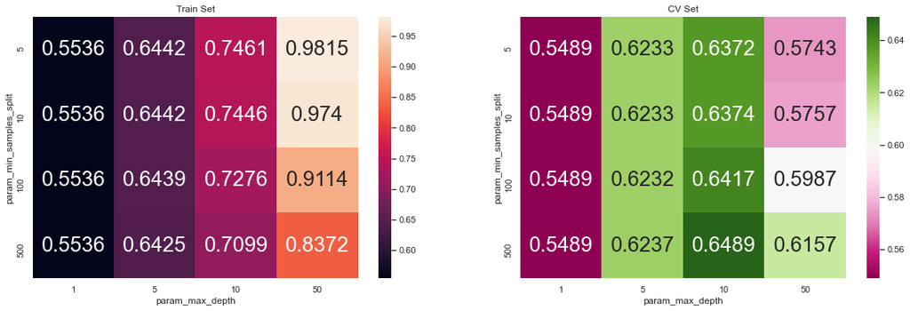

```python
import seaborn as sns; sns.set()
max_scores1 = pd.DataFrame(clf1.cv_results_).groupby(['param_min_samples_split', 'param_max_depth']).max().unstack()[['mean_test_score', 'mean_train_score']]
fig, ax = plt.subplots(1,2, figsize=(20,6))
sns.heatmap(max_scores1.mean_train_score, annot = True, fmt='.4g', ax=ax[0],annot_kws={"size": 26})
sns.heatmap(max_scores1.mean_test_score, annot = True, fmt='.4g', ax=ax[1],annot_kws={"size": 26},cmap="PiYG")
ax[0].set_title('Train Set')
ax[1].set_title('CV Set')
plt.show()
```

### 4.3 To test the performance of model on test data: ROC Curve

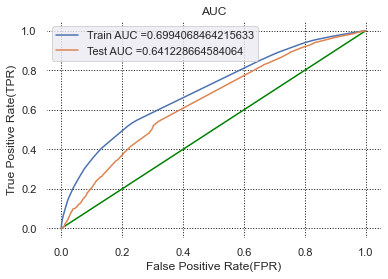

```python
#https://scikitlearn.org/stable/modules/generated/sklearn.metrics.roc_curve.html#sklearn.metrics.roc_curve
from sklearn.metrics import roc_curve, auc

dt_tfidf_testModel1 = DecisionTreeClassifier(class_weight='balanced',min_samples_split=bestMinSampleSplit_1,max_depth=bestMaxdepth_1)
dt_tfidf_testModel1.fit(x_train_one_hot_tfidf, y_train)

y_train_pred_1=dt_tfidf_testModel1.predict_proba(x_train_one_hot_tfidf)[:,1]
predictions_train_set_=dt_tfidf_testModel1.predict(x_train_one_hot_tfidf)

y_test_pred_1=dt_tfidf_testModel1.predict_proba(x_test_one_hot_tfidf)[:,1]
predictions_test_set1=dt_tfidf_testModel1.predict(x_test_one_hot_tfidf)


train_fpr1, train_tpr1, tr_thresholds1 = roc_curve(y_train, y_train_pred_1)
test_fpr1, test_tpr1, te_thresholds1 = roc_curve(y_test, y_test_pred_1)

ax = plt.subplot()

auc_set1_train=auc(train_fpr1, train_tpr1)
auc_set1_test=auc(test_fpr1, test_tpr1)

plt.plot([0, 1], [0, 1], color='green')
ax.plot(train_fpr1, train_tpr1, label="Train AUC ="+str(auc(train_fpr1, train_tpr1)))
ax.plot(test_fpr1, test_tpr1, label="Test AUC ="+str(auc(test_fpr1, test_tpr1)))
plt.legend()
plt.xlabel("False Positive Rate(FPR)")
plt.ylabel("True Positive Rate(TPR)")
plt.title("AUC")
plt.grid(b=True, which='major', color='k', linestyle=':')
ax.set_facecolor("white")
plt.show()
```

### 4.4 Confusion Matrix: SET1

```python
def predict(proba, threshould, fpr, tpr):
    t = threshould[np.argmax(tpr*(1-fpr))]
    # (tpr*(1-fpr)) will be maximum if your fpr is very low and tpr is very high
    print("the maximum value of tpr*(1-fpr)", max(tpr*(1-fpr)), "for threshold", np.round(t,3))
    predictions = []
    for i in proba:
        if i>=t:
            predictions.append(1)
        else:
            predictions.append(0)
    return predictions
```

#### Confusion matrix: x_train

```
Train confusion matrix
the maximum value of tpr*(1-fpr) 0.4116262572864295 for threshold 0.429
[[ 9004  3142]
 [30177 37677]]
====================================================================================================
```

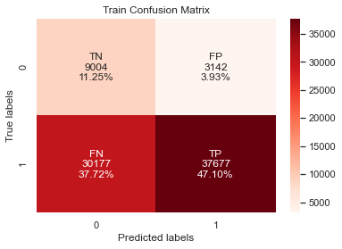

```python
#code from: https://medium.com/@dtuk81/confusion-matrix-visualization-fc31e3f30fea
#code from: https://stackoverflow.com/questions/19233771/sklearn-plot-confusion-matrix-with-labels/19252430

print("Train confusion matrix")

conf_matr_train_set1 = confusion_matrix(y_train, predict(y_train_pred_1, tr_thresholds1,train_fpr1, train_tpr1))
print(conf_matr_train_set1)
print("="*100)
group_names = ["TN","FP","FN","TP"] #labels of actual and predicted values(each quadrant)
group_counts = ["{0:0.0f}".format(value) for value in conf_matr_train_set1.flatten()]

#percentage of data is represented in each quadrant
group_percentages = ["{0:.2%}".format(value) for value in conf_matr_train_set1.flatten()/np.sum(conf_matr_train_set1)]

labels = [f"{v1}\n{v2}\n{v3}" for v1, v2, v3 in zip(group_names,group_counts,group_percentages)]
labels = np.asarray(labels).reshape(2,2)
ax= plt.subplot()
sns.heatmap(conf_matr_train_set1, annot=labels, fmt='',cmap='Reds',ax=ax)

ax.set_xlabel('Predicted labels');ax.set_ylabel('True labels');
ax.set_title('Train Confusion Matrix');
ax.xaxis.set_ticklabels(['0', '1']); ax.yaxis.set_ticklabels(['0', '1']);
ax.set_xlabel('Predicted labels');ax.set_ylabel('True labels');
```

#### Confusion matrix: x_test

```
Test confusion matrix
the maximum value of tpr*(1-fpr) 0.3685771299757548 for threshold 0.428
[[2063  974]
 [7759 9204]]
====================================================================================================
```

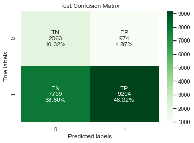

```python
#code from: https://medium.com/@dtuk81/confusion-matrix-visualization-fc31e3f30fea
#code from: https://stackoverflow.com/questions/19233771/sklearn-plot-confusion-matrix-with-labels/19252430

print("Test confusion matrix")

conf_matr_test_set1 = confusion_matrix(y_test, predict(y_test_pred_1, tr_thresholds1, test_fpr1, test_tpr1))
print(conf_matr_test_set1)
print("="*100)
group_names = ["TN","FP","FN","TP"] #labels of actual and predicted values(each quadrant)
group_counts = ["{0:0.0f}".format(value) for value in conf_matr_test_set1.flatten()]

#percentage of data is represented in each quadrant
group_percentages = ["{0:.2%}".format(value) for value in conf_matr_test_set1.flatten()/np.sum(conf_matr_test_set1)]

labels = [f"{v1}\n{v2}\n{v3}" for v1, v2, v3 in zip(group_names,group_counts,group_percentages)]
labels = np.asarray(labels).reshape(2,2)
ax= plt.subplot()
sns.heatmap(conf_matr_test_set1, annot=labels, fmt='',cmap='Greens',ax=ax)

ax.set_xlabel('Predicted labels');ax.set_ylabel('True labels');
ax.set_title('Test Confusion Matrix');
ax.xaxis.set_ticklabels(['0', '1']); ax.yaxis.set_ticklabels(['0', '1']);
ax.set_xlabel('Predicted labels');ax.set_ylabel('True labels');
```

### 4.5 Retrieving all the false positive data points

```python
#to collect all the predicitions of y_test of SET1
predictions_set1 = predict(y_test_pred_1, tr_thresholds1, test_fpr1, test_tpr1)
```

```
the maximum value of tpr*(1-fpr) 0.3685771299757548 for threshold 0.428
```

```python
FP_indices_set1 =[] #to store index of false positive data points
for index in range(len(y_test)):
    if (y_test[index] == 0) and (predictions_set1[index] == 1):
        FP_indices_set1.append(index)

FP_essay_set1 = [] #to store words of essay text of Fale positive data points
for i in FP_indices_set1 :
    FP_essay_set1.append(x_test['preprocessed_essays'].values[i])

FP_price_set1 = []
for j in  FP_indices_set1:
    FP_price_set1.append(x_test['price'].values[j])


FP_prev_proj_set1 = []
for p in  FP_indices_set1:
    FP_prev_proj_set1.append(x_test['teacher_number_of_previously_posted_projects'].values[p])
```

### 4.6 WorldCloud with the words of essay text of these 'false positive data points':SET1

```python
# importing all necessary modules
from wordcloud import WordCloud, STOPWORDS
import matplotlib.pyplot as plt
from PIL import Image # for masking i.e print word in the pattern we want
import pandas as pd

# Read 'Youtube04-Eminem.csv' files
# using encoding = "latin-1" to get vertical words arrangement along with horizontal once
# dataFrame = pd.read_csv(r"Youtube04-Eminem.csv", encoding = "latin-1")
# dataFrame.head()
def printWordCloud(FP_list):
    comment_words = ''
    stopwords = set(STOPWORDS)

    # for val in dataFrame.CONTENT:
    for val in FP_list:

        # typecaste each val to string
        val = str(val)

        # split the value
        tokens = val.split()

        # Converts each token into lowercase
        for i in range(len(tokens)):
            tokens[i] = tokens[i].lower()

        for words in tokens:
            comment_words = comment_words + words + ' '


    wordcloud = WordCloud(width = 500, height = 500,
                    background_color ='white',
                    stopwords = stopwords,
                    min_font_size = 10).generate(comment_words)

    # plot the WordCloud image
    plt.figure(figsize = (6,6), facecolor = None)
    plt.imshow(wordcloud)
    plt.axis("off")
    plt.tight_layout(pad = 0)
```

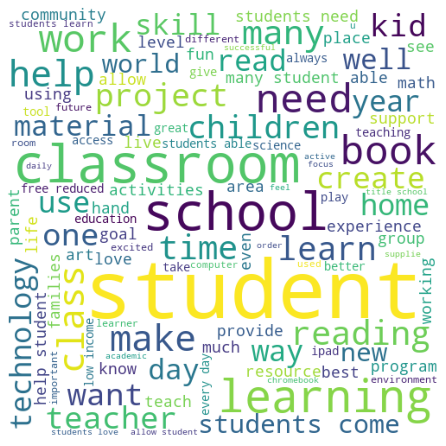

```python
printWordCloud(FP_essay_set1)
```

### 4.7 Box plot with the `price` of these `false positive data points`

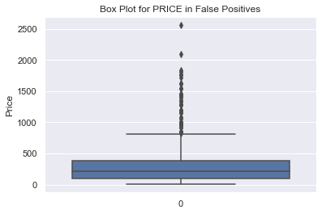

```python
sns.boxplot(data=FP_price_set1)
plt.title('Box Plot for PRICE in False Positives')
plt.ylabel('Price')
plt.show()
```

### 4.8 PDF with the `teacher_number_of_previously_posted_projects` of these `false positive data points`

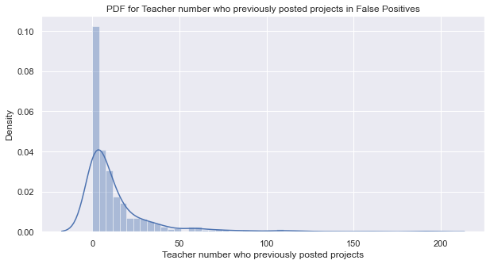

```python
plt.figure(figsize=(10,5))
sns.distplot(FP_prev_proj_set1)
plt.title('PDF for Teacher number who previously posted projects in False Positives')
plt.xlabel('Teacher number who previously posted projects')
plt.show()
```

## 5. Apply Decision Tree Cassifier(DecisionTreeClassifier) on SET2

### 5.1 Hyper paramter tuning to find best 'max_depth' and 'min_sample_split' using GRIDSEARCHCV

best `max_depth` in range [1, 5, 10, 50], and the best `min_samples_split` in range [5, 10, 100, 500]

```python
from sklearn.model_selection import GridSearchCV
import matplotlib.pyplot as plt
from sklearn.tree import DecisionTreeClassifier
from sklearn.metrics import roc_auc_score
import math

dt_tfidf_2 = DecisionTreeClassifier(class_weight='balanced')
parameters = {'max_depth':[1, 5, 10, 50],'min_samples_split':[5, 10, 100, 500]}
clf2 = GridSearchCV(dt_tfidf_2, parameters, cv= 3, scoring='roc_auc',verbose=1,return_train_score=True,n_jobs=-1)

clf2.fit(x_train_one_hot_tfidf_w2v,y_train)
train_auc= clf2.cv_results_['mean_train_score']
train_auc_std= clf2.cv_results_['std_train_score']
cv_auc = clf2.cv_results_['mean_test_score']
cv_auc_std= clf2.cv_results_['std_test_score']
bestMaxdepth_2=clf2.best_params_['max_depth']
bestMinSampleSplit_2 = clf2.best_params_['min_samples_split']
bestScore_2=clf2.best_score_
print("BEST MAX DEPTH: ",bestMaxdepth_2)
print("BEST MIN SAMPLES SPLIT:",bestMinSampleSplit_2)
print("BEST SCORE: ",bestScore_2)
```

```
Fitting 3 folds for each of 16 candidates, totalling 48 fits
```

```
[Parallel(n_jobs=-1)]: Using backend LokyBackend with 8 concurrent workers.
[Parallel(n_jobs=-1)]: Done  48 out of  48 | elapsed: 20.8min finished
```

```
BEST MAX DEPTH:  5
BEST MIN SAMPLES SPLIT: 500
BEST SCORE:  0.6296433382136991
```

### 5.2 Heatmap of tuned hyper paramters: SET2

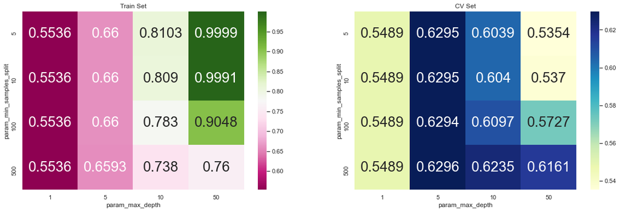

```python
import seaborn as sns; sns.set()
max_scores2 = pd.DataFrame(clf2.cv_results_).groupby(['param_min_samples_split', 'param_max_depth']).max().unstack()[['mean_test_score', 'mean_train_score']]
fig, ax = plt.subplots(1,2, figsize=(20,6))
sns.heatmap(max_scores2.mean_train_score, annot = True, fmt='.4g', ax=ax[0],annot_kws={"size": 26},cmap="PiYG")
sns.heatmap(max_scores2.mean_test_score, annot = True, fmt='.4g', ax=ax[1],annot_kws={"size": 26},cmap="YlGnBu")
ax[0].set_title('Train Set')
ax[1].set_title('CV Set')
plt.show()
```

### 4.3 To test the performance of model on test data: ROC Curve

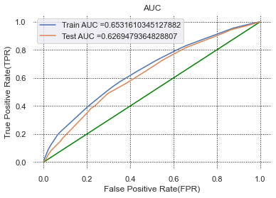

```python
#https://scikitlearn.org/stable/modules/generated/sklearn.metrics.roc_curve.html#sklearn.metrics.roc_curve
from sklearn.metrics import roc_curve, auc

dt_tfidf_testModel2 = DecisionTreeClassifier(class_weight='balanced',min_samples_split=bestMinSampleSplit_2,max_depth=bestMaxdepth_2)
dt_tfidf_testModel2.fit(x_train_one_hot_tfidf_w2v, y_train)

y_train_pred_2=dt_tfidf_testModel2.predict_proba(x_train_one_hot_tfidf_w2v)[:,1]
predictions_train_set2=dt_tfidf_testModel2.predict(x_train_one_hot_tfidf_w2v)

y_test_pred_2=dt_tfidf_testModel2.predict_proba(x_test_one_hot_tfidf_w2v)[:,1]
predictions_test_set2=dt_tfidf_testModel2.predict(x_test_one_hot_tfidf_w2v)


train_fpr2, train_tpr2, tr_thresholds2 = roc_curve(y_train, y_train_pred_2)
test_fpr2, test_tpr2, te_thresholds2 = roc_curve(y_test, y_test_pred_2)

ax = plt.subplot()

auc_set2_train=auc(train_fpr2, train_tpr2)
auc_set2_test=auc(test_fpr2, test_tpr2)

plt.plot([0, 1], [0, 1], color='green')
ax.plot(train_fpr2, train_tpr2, label="Train AUC ="+str(auc(train_fpr2, train_tpr2)))
ax.plot(test_fpr2, test_tpr2, label="Test AUC ="+str(auc(test_fpr2, test_tpr2)))
plt.legend()
plt.xlabel("False Positive Rate(FPR)")
plt.ylabel("True Positive Rate(TPR)")
plt.title("AUC")
plt.grid(b=True, which='major', color='k', linestyle=':')
ax.set_facecolor("white")
plt.show()
```

### 5.4 Confusion Matrix

#### Confusion matrix: x_train

```
Train confusion matrix
the maximum value of tpr*(1-fpr) 0.37105882904864984 for threshold 0.518
[[ 7888  4258]
 [29085 38769]]
====================================================================================================
```

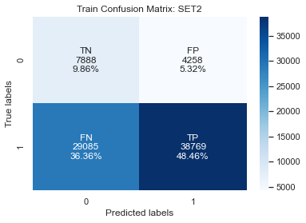

```python
#code from: https://medium.com/@dtuk81/confusion-matrix-visualization-fc31e3f30fea
#code from: https://stackoverflow.com/questions/19233771/sklearn-plot-confusion-matrix-with-labels/19252430

print("Train confusion matrix")

conf_matr_train2 = confusion_matrix(y_train, predict(y_train_pred_2, tr_thresholds2,train_fpr2, train_tpr2))
print(conf_matr_train2)
print("="*100)
group_names = ["TN","FP","FN","TP"] #labels of actual and predicted values(each quadrant)
group_counts = ["{0:0.0f}".format(value) for value in conf_matr_train2.flatten()]

#percentage of data is represented in each quadrant
group_percentages = ["{0:.2%}".format(value) for value in conf_matr_train2.flatten()/np.sum(conf_matr_train2)]

labels = [f"{v1}\n{v2}\n{v3}" for v1, v2, v3 in zip(group_names,group_counts,group_percentages)]
labels = np.asarray(labels).reshape(2,2)
ax= plt.subplot()
sns.heatmap(conf_matr_train2, annot=labels, fmt='',cmap='Blues',ax=ax)

ax.set_xlabel('Predicted labels');ax.set_ylabel('True labels');
ax.set_title('Train Confusion Matrix: SET2');
ax.xaxis.set_ticklabels(['0', '1']); ax.yaxis.set_ticklabels(['0', '1']);
ax.set_xlabel('Predicted labels');ax.set_ylabel('True labels');
```

### Confusion Matrix: x_test

```
Test confusion matrix
the maximum value of tpr*(1-fpr) 0.34735423595537523 for threshold 0.518
[[1890 1147]
 [7495 9468]]
====================================================================================================
```

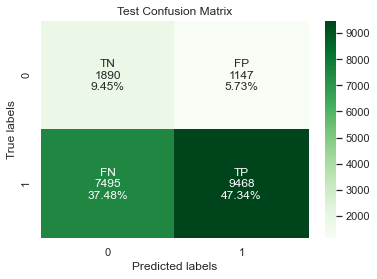

```python
#code from: https://medium.com/@dtuk81/confusion-matrix-visualization-fc31e3f30fea
#code from: https://stackoverflow.com/questions/19233771/sklearn-plot-confusion-matrix-with-labels/19252430

print("Test confusion matrix")

conf_matr_test2 = confusion_matrix(y_test, predict(y_test_pred_2, tr_thresholds2, test_fpr2, test_tpr2))
print(conf_matr_test2)
print("="*100)
group_names = ["TN","FP","FN","TP"] #labels of actual and predicted values(each quadrant)
group_counts = ["{0:0.0f}".format(value) for value in conf_matr_test2.flatten()]

#percentage of data is represented in each quadrant
group_percentages = ["{0:.2%}".format(value) for value in conf_matr_test2.flatten()/np.sum(conf_matr_test2)]

labels = [f"{v1}\n{v2}\n{v3}" for v1, v2, v3 in zip(group_names,group_counts,group_percentages)]
labels = np.asarray(labels).reshape(2,2)
ax= plt.subplot()
sns.heatmap(conf_matr_test2, annot=labels, fmt='',cmap='Greens',ax=ax)

ax.set_xlabel('Predicted labels');ax.set_ylabel('True labels');
ax.set_title('Test Confusion Matrix');
ax.xaxis.set_ticklabels(['0', '1']); ax.yaxis.set_ticklabels(['0', '1']);
ax.set_xlabel('Predicted labels');ax.set_ylabel('True labels');
```

### 5.5 Retrieving all the false positive data points

```python
predictions_set2 = predict(y_test_pred_2, tr_thresholds2, test_fpr2, test_tpr2)
```

```
the maximum value of tpr*(1-fpr) 0.34735423595537523 for threshold 0.518
```

```python
FP_indices_set2 =[] #to store index of false positive data points
for index in range(len(y_test)):
    if (y_test[index] == 0) and (predictions_set2[index] == 1):
        FP_indices_set2.append(index)

FP_essay_set2 = [] #to store words of essay text of Fale positive data points
for i in FP_indices_set2 :
    FP_essay_set2.append(x_test['preprocessed_essays'].values[i])

FP_price_set2 = []
for j in  FP_indices_set2:
    FP_price_set2.append(x_test['price'].values[j])


FP_prev_proj_set2 = []
for p in  FP_indices_set2:
    FP_prev_proj_set2.append(x_test['teacher_number_of_previously_posted_projects'].values[p])
```

### 5.6 WorldCloud with the words of essay text of these 'false positive data points':SET2

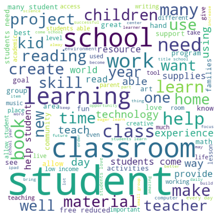

```python
printWordCloud(FP_essay_set2)
```

### 5.7 Box Plot with price values of "False positive data"

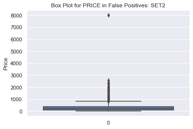

```python
sns.boxplot(data=FP_price_set2)
plt.title('Box Plot for PRICE in False Positives: SET2')
plt.ylabel('Price')
plt.show()
```

### 5.8 PDF with the `teacher_number_of_previously_posted_projects` of these `false positive data points`:SET2

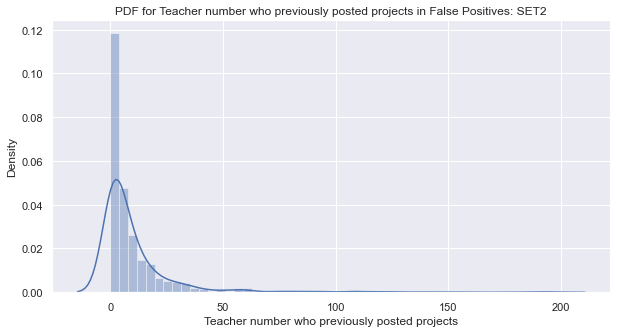

```python
plt.figure(figsize=(10,5))
sns.distplot(FP_prev_proj_set2)
plt.title('PDF for Teacher number who previously posted projects in False Positives: SET2')
plt.xlabel('Teacher number who previously posted projects')
plt.show()
```

```python
## #https://stackoverflow.com/questions/47111434/randomforestregressor-and-feature-importances-error

from sklearn.model_selection import GridSearchCV
def selectKImportance(model, X, k):
    return X[:,model.feature_importances_.argsort()[::-1][:k]]
```

```python
#https://scikitlearn.org/stable/modules/generated/sklearn.metrics.roc_curve.html#sklearn.metrics.roc_curve
from sklearn.metrics import roc_curve, auc

dt_tfidf_imp_feature_testModel = DecisionTreeClassifier(class_weight='balanced')
dt_tfidf_imp_feature_testModel.fit(x_train_one_hot_tfidf, y_train)

important_features = 0 #Non-zero important features
for i in range(len(dt_tfidf_imp_feature_testModel.feature_importances_)):
    if (dt_tfidf_imp_feature_testModel.feature_importances_[i] > 0):
        important_features+=1
```

```python
#Number of important features(Non-zero features) in SET1
important_features
```

```
3129
```

```python
x_train_imp_features=selectKImportance(dt_tfidf_imp_feature_testModel,x_train_one_hot_tfidf,important_features)
x_test_imp_features=selectKImportance(dt_tfidf_imp_feature_testModel,x_test_one_hot_tfidf,important_features)

print("Shape of x_train_imp_features",x_train_imp_features.shape)
print("Shape of x_test_imp_features",x_test_imp_features.shape)
```

```
Shape of x_train_imp_features (80000, 3129)
Shape of x_test_imp_features (20000, 3129)
```

```python
dt_tfidf_imp_features = DecisionTreeClassifier(class_weight='balanced')
parameters = {'max_depth':[1, 5, 10, 50],'min_samples_split':[5, 10, 100, 500]}
clf = GridSearchCV(dt_tfidf_imp_features, parameters, cv= 3, scoring='roc_auc',verbose=1,return_train_score=True,n_jobs=-1)

clf.fit(x_train_one_hot_tfidf,y_train)
train_auc= clf.cv_results_['mean_train_score']
train_auc_std= clf.cv_results_['std_train_score']
cv_auc = clf.cv_results_['mean_test_score']
cv_auc_std= clf.cv_results_['std_test_score']
bestMaxdepth_imp=clf.best_params_['max_depth']
bestMinSampleSplit_imp = clf.best_params_['min_samples_split']
bestScore_imp=clf.best_score_
print("BEST MAX DEPTH: ",bestMaxdepth_imp)
print("BEST MIN SAMPLES SPLIT:",bestMinSampleSplit_imp)
print("BEST SCORE: ",bestScore_imp)
```

```
Fitting 3 folds for each of 16 candidates, totalling 48 fits
```

```
[Parallel(n_jobs=-1)]: Using backend LokyBackend with 8 concurrent workers.
[Parallel(n_jobs=-1)]: Done  48 out of  48 | elapsed: 18.7min finished
```

```
BEST MAX DEPTH:  10
BEST MIN SAMPLES SPLIT: 500
BEST SCORE:  0.6487334459539604
```

### 2.2 Heatmap for the tuned hyper parameters

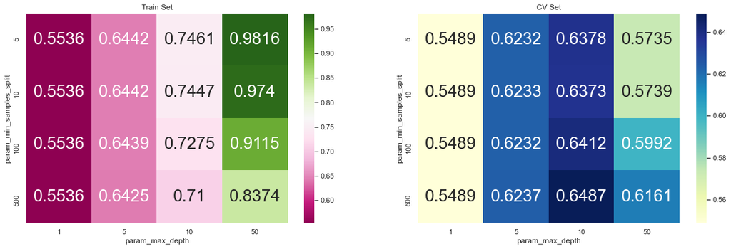

```python
import seaborn as sns; sns.set()
max_scores_imp_feat = pd.DataFrame(clf.cv_results_).groupby(['param_min_samples_split', 'param_max_depth']).max().unstack()[['mean_test_score', 'mean_train_score']]
fig, ax = plt.subplots(1,2, figsize=(20,6))
sns.heatmap(max_scores_imp_feat.mean_train_score, annot = True, fmt='.4g', ax=ax[0],annot_kws={"size": 26},cmap="PiYG")
sns.heatmap(max_scores_imp_feat.mean_test_score, annot = True, fmt='.4g', ax=ax[1],annot_kws={"size": 26},cmap="YlGnBu")
ax[0].set_title('Train Set')
ax[1].set_title('CV Set')
plt.show()
```

### 2.3 To test performance of model: ROC curve

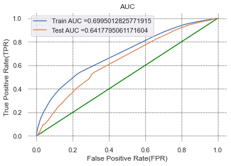

```python
#https://scikitlearn.org/stable/modules/generated/sklearn.metrics.roc_curve.html#sklearn.metrics.roc_curve
from sklearn.metrics import roc_curve, auc

dt_tfidf_testModel_imp = DecisionTreeClassifier(class_weight='balanced',min_samples_split=bestMinSampleSplit_imp,max_depth=bestMaxdepth_imp)
dt_tfidf_testModel_imp.fit(x_train_one_hot_tfidf, y_train)

y_train_pred_imp=dt_tfidf_testModel_imp.predict_proba(x_train_one_hot_tfidf)[:,1]
predictions_train_imp=dt_tfidf_testModel_imp.predict(x_train_one_hot_tfidf)

y_test_pred_imp=dt_tfidf_testModel_imp.predict_proba(x_test_one_hot_tfidf)[:,1]
predictions_test_imp=dt_tfidf_testModel_imp.predict(x_test_one_hot_tfidf)


train_fpr, train_tpr, tr_thresholds = roc_curve(y_train, y_train_pred_imp)
test_fpr, test_tpr, te_thresholds = roc_curve(y_test, y_test_pred_imp)

ax = plt.subplot()

auc_set1_imp_feat_train = auc(train_fpr, train_tpr)
auc_set1_imp_feat_test = auc(test_fpr, test_tpr)

plt.plot([0, 1], [0, 1], color='green')
ax.plot(train_fpr, train_tpr, label="Train AUC ="+str(auc(train_fpr, train_tpr)))
ax.plot(test_fpr, test_tpr, label="Test AUC ="+str(auc(test_fpr, test_tpr)))
plt.legend()
plt.xlabel("False Positive Rate(FPR)")
plt.ylabel("True Positive Rate(TPR)")
plt.title("AUC")
plt.grid(b=True, which='major', color='k', linestyle=':')
ax.set_facecolor("white")
plt.show()
```

### 2.4 Confusion Matrix

confusion matrix : x_train

```
Train confusion matrix of Important features
the maximum value of tpr*(1-fpr) 0.4117912287446273 for threshold 0.429
[[ 9010  3136]
 [30187 37667]]
====================================================================================================
```

[figure not shown]

```python
#code from: https://medium.com/@dtuk81/confusion-matrix-visualization-fc31e3f30fea
#code from: https://stackoverflow.com/questions/19233771/sklearn-plot-confusion-matrix-with-labels/19252430

print("Train confusion matrix of Important features")

conf_matr_train = confusion_matrix(y_train, predict(y_train_pred_imp, tr_thresholds,train_fpr, train_tpr))
print(conf_matr_train)
print("="*100)
group_names = ["TN","FP","FN","TP"] #labels of actual and predicted values(each quadrant)
group_counts = ["{0:0.0f}".format(value) for value in conf_matr_train.flatten()]

#percentage of data is represented in each quadrant
group_percentages = ["{0:.2%}".format(value) for value in conf_matr_train.flatten()/np.sum(conf_matr_train)]

labels = [f"{v1}\n{v2}\n{v3}" for v1, v2, v3 in zip(group_names,group_counts,group_percentages)]
labels = np.asarray(labels).reshape(2,2)
ax= plt.subplot()
sns.heatmap(conf_matr_train, annot=labels, fmt='',cmap='BuPu',ax=ax)

ax.set_xlabel('Predicted labels');ax.set_ylabel('True labels');
ax.set_title('Train Confusion Matrix: SET2');
ax.xaxis.set_ticklabels(['0', '1']); ax.yaxis.set_ticklabels(['0', '1']);
ax.set_xlabel('Predicted labels');ax.set_ylabel('True labels');
```

#### Confusion matrix: x_test

```
Test confusion matrix of Important features
the maximum value of tpr*(1-fpr) 0.36885744721932606 for threshold 0.428
[[2063  974]
 [7752 9211]]
====================================================================================================
```

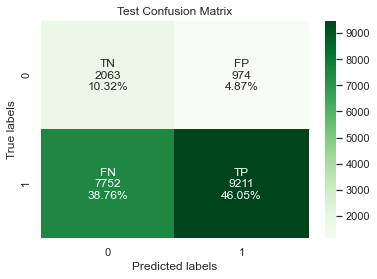

```python
#code from: https://medium.com/@dtuk81/confusion-matrix-visualization-fc31e3f30fea
#code from: https://stackoverflow.com/questions/19233771/sklearn-plot-confusion-matrix-with-labels/19252430

print("Test confusion matrix of Important features")

conf_matr_test = confusion_matrix(y_test, predict(y_test_pred_imp, tr_thresholds, test_fpr, test_tpr))
print(conf_matr_test)
print("="*100)
group_names = ["TN","FP","FN","TP"] #labels of actual and predicted values(each quadrant)
group_counts = ["{0:0.0f}".format(value) for value in conf_matr_test.flatten()]

#percentage of data is represented in each quadrant
group_percentages = ["{0:.2%}".format(value) for value in conf_matr_test.flatten()/np.sum(conf_matr_test)]

labels = [f"{v1}\n{v2}\n{v3}" for v1, v2, v3 in zip(group_names,group_counts,group_percentages)]
labels = np.asarray(labels).reshape(2,2)
ax= plt.subplot()
sns.heatmap(conf_matr_test2, annot=labels, fmt='',cmap='Greens',ax=ax)

ax.set_xlabel('Predicted labels');ax.set_ylabel('True labels');
ax.set_title('Test Confusion Matrix');
ax.xaxis.set_ticklabels(['0', '1']); ax.yaxis.set_ticklabels(['0', '1']);
ax.set_xlabel('Predicted labels');ax.set_ylabel('True labels');
```

### 2.5 Collecting all False positive data points

```python
#to collect all the predicitions of y_test of important features of SET1
predictions_imp_feat = predict(y_test_pred_imp, tr_thresholds, test_fpr, test_tpr)
```

```
the maximum value of tpr*(1-fpr) 0.36885744721932606 for threshold 0.428
```

```python
FP_indices =[] #to store index of false positive data points
for index in range(len(y_test)):
    if (y_test[index] == 0) and (predictions_imp_feat[index] == 1):
        FP_indices.append(index)

FP_essay = [] #to store words of essay text of Fale positive data points
for i in FP_indices:
    FP_essay.append(x_test['preprocessed_essays'].values[i])

FP_price = []
for j in  FP_indices:
    FP_price.append(x_test['price'].values[j])


FP_prev_proj = []
for p in  FP_indices:
    FP_prev_proj.append(x_test['teacher_number_of_previously_posted_projects'].values[p])
```

### 2.6 WordCloud of words of essay of important features (set1)

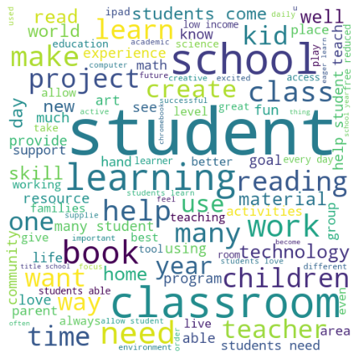

```python
printWordCloud(FP_essay)
```

### 2.7 Box Plot with price values of False positive data points

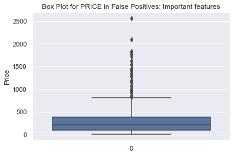

```python
sns.boxplot(data=FP_price)
plt.title('Box Plot for PRICE in False Positives: Important features')
plt.ylabel('Price')
plt.show()
```

### 2.8 PDF with the `teacher_number_of_previously_posted_projects` of these `false positive data points

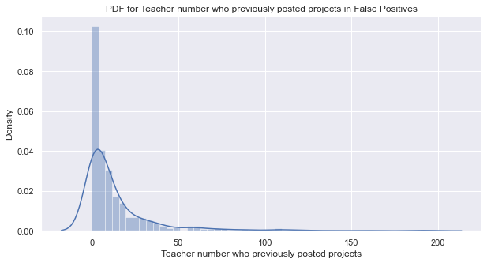

```python
plt.figure(figsize=(10,5))
sns.distplot(FP_prev_proj)
plt.title('PDF for Teacher number who previously posted projects in False Positives')
plt.xlabel('Teacher number who previously posted projects')
plt.show()
```

## Conclusion:

```python
from prettytable import PrettyTable

x = PrettyTable()

x.field_names = ["Vectorizer", "Model", "Min. Sample Split","Max Dept", "Train AUC", "Test AUC"]
# auc_set2_train=auc(train_fpr, train_tpr)
# auc_set2_test=auc(test_fpr, test_tpr)

x.add_row(["TF-IDF", "DT", bestMinSampleSplit_1,bestMaxdepth_1,auc_set1_train,auc_set1_test])
x.add_row(["TFIDF_W2V", "DT", bestMinSampleSplit_2,bestMaxdepth_2,auc_set2_train,auc_set2_test])
x.add_row(["TF-IDF (Imp. Feature)", "DT", bestMinSampleSplit_imp,bestMaxdepth_imp,auc_set1_imp_feat_train,auc_set1_imp_feat_test])


print(x)
```

```
+-----------------------+-------+-------------------+----------+--------------------+--------------------+
|       Vectorizer      | Model | Min. Sample Split | Max Dept |     Train AUC      |      Test AUC      |
+-----------------------+-------+-------------------+----------+--------------------+--------------------+
|         TF-IDF        |   DT  |        500        |    10    | 0.6994068464215633 | 0.641228664584064  |
|       TFIDF_W2V       |   DT  |        500        |    5     | 0.6531610345127882 | 0.6269479364828807 |
| TF-IDF (Imp. Feature) |   DT  |        500        |    10    | 0.6995012825771915 | 0.6417795061171604 |
+-----------------------+-------+-------------------+----------+--------------------+--------------------+
```

### Reference:

- https://www.kaggle.com/nikhilparmar9/decision-tree-donorschoose-dataset
- https://medium.com/@dtuk81/confusion-matrix-visualization-fc31e3f30fea
- https://www.appliedaicourse.com/course/11/Applied-Machine-learning-course